# Titanic Project

apb766, mew2795, jdg3666

September 13, 2015

1. This program uses SQL to assign all of the Titanic data to a dataframe and then prints out a subset and summary of the data.

```r
source("../01 Data/Database.R", echo = TRUE)
```

```
##
## > require(jsonlite)
```

```
##
## > require(RCurl)
```

```
##
## > require(ggplot2)
```

```
##
## > df <- data.frame(fromJSON(getURL(URLencode("129.152.144.84:5001/rest/native/?query=\"select * from titanic\""),
## +     httpheader = c(DB = "jdbc:ora ..." ... [TRUNCATED]
##
## > summary(df)
##                                       PASSENGERID  SURVIVED    PCLASS
##  </pre></body></html>Xtext/csvUUTF-8(?N`vPJS:  1   0   :549   1   :216
##  1                                          :  1   1   :342   2   :184
##  10                                         :  1   null:  2   3   :491
##  100                                        :  1              null:  2
##  101                                        :  1
##  102                                        :  1
##  (Other)                                    :887
##                                     NAME         SEX           AGE
##  null                                 :  2   female:314   null   :179
##  Abbing, Mr. Anthony                  :  1   male  :577   24     : 30
##  Abbott, Mr. Rossmore Edward          :  1   null  :  2   22     : 27
##  Abbott, Mrs. Stanton (Rosa Hunt)     :  1                18     : 26
##  Abelson, Mr. Samuel                  :  1                19     : 25
##  Abelson, Mrs. Samuel (Hannah Wizosky):  1                28     : 25
##  (Other)                              :886                (Other):581
##      SIBSP         PARCH          TICKET                  FARE
##  0      :608   0      :678   1601    :  7   8.05000019073486: 43
##  1      :209   1      :118   347082  :  7   13              : 42
##  2      : 28   2      : 80   CA. 2343:  7   7.89580011367798: 38
##  4      : 18   3      :  5   3101295 :  6   7.75            : 34
##  3      : 16   5      :  5   347088  :  6   26              : 31
##  8      :  7   4      :  4   CA 2144 :  6   10.5            : 24
##  (Other):  7   (Other):  3   (Other) :854   (Other)         :681
##          CABIN     EMBARKED
##  null       :689   C   :168
##  B96 B98    :  4   null:  4
##  C23 C25 C27:  4   Q   : 77
##  G6         :  4   S   :644
##  C22 C26    :  3
##  D          :  3
##  (Other)    :186
##
## > head(df)
##   PASSENGERID SURVIVED PCLASS
## 1         414        0      2
## 2         415        1      3
## 3         416        0      3
## 4         417        1      2
## 5         418        1      2
## 6         419        0      2
##                                              NAME    SEX  AGE SIBSP PARCH
## 1                  Cunningham, Mr. Alfred Fleming   male null     0     0
## 2                       Sundman, Mr. Johan Julian   male   44     0     0
## 3         Meek, Mrs. Thomas (Annie Louise Rowley) female null     0     0
## 4 Drew, Mrs. James Vivian (Lulu Thorne Christian) female   34     1     1
## 5                   Silven, Miss. Lyyli Karoliina female   18     0     2
## 6                      Matthews, Mr. William John   male   30     0     0
##              TICKET             FARE CABIN EMBARKED
## 1            239853                0  null        S
## 2 STON/O 2. 3101269 7.92500019073486  null        S
## 3            343095 8.05000019073486  null        S
## 4             28220             32.5  null        S
## 5            250652               13  null        S
## 6             28228               13  null        S
```

2. These sections of code run ggplot() programs which produce each of the required plots of Titanic Data.

This first plot uses the whole database (including entries where sex is null) and displays Age compared to Fare.

```
##
## > require(jsonlite)
##
## > require(RCurl)
##
## > require(ggplot2)
##
## > df <- data.frame(fromJSON(getURL(URLencode("129.152.144.84:5001/rest/native/?query=\"select * from titanic \""),
## +     httpheader = c(DB = "jdbc:or ..." ... [TRUNCATED]
##
## > ggplot() + coord_cartesian() + scale_x_continuous() +
## +     scale_y_continuous() + labs(title = "Titanic") + labs(x = "Age",
## +     y = paste("Fare ..." ... [TRUNCATED]
```

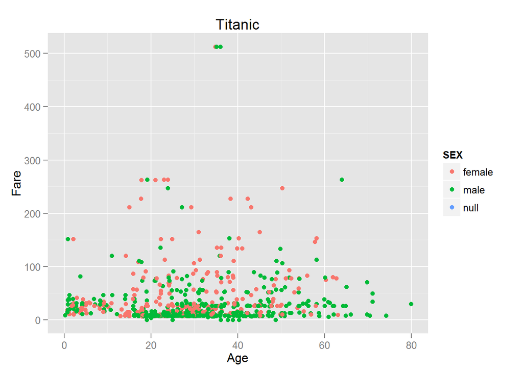

```r
source("../02 Visualizations/TitanicPlot01.R", echo = TRUE)
```

The second plot displays the same information as the first but redefines the dataframe to exclude entries where sex is null.

```
##
## > df <- data.frame(fromJSON(getURL(URLencode("129.152.144.84:5001/rest/native/?query=\"select * from titanic where sex is not null\""),
## +     httphea .... [TRUNCATED]
##
## > ggplot() + coord_cartesian() + scale_x_continuous() +
## +     scale_y_continuous() + labs(title = "Titanic") + labs(x = "Age",
## +     y = paste("Fare ..." ... [TRUNCATED]
```

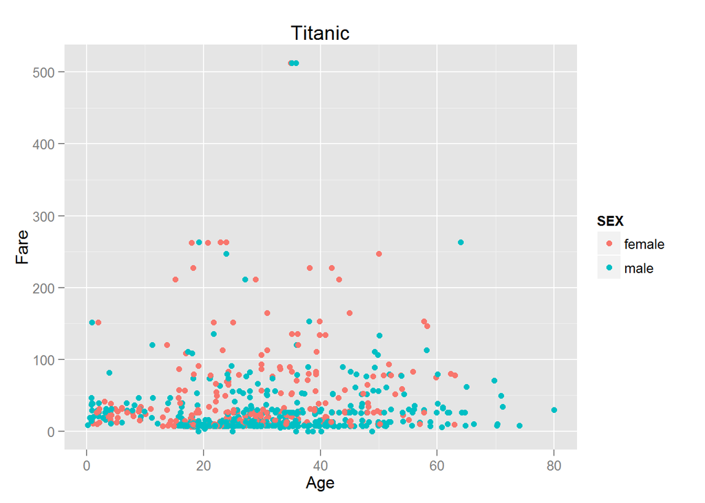

```r
source("../02 Visualizations/TitanicPlot02.R", echo = TRUE)
```

The third plot uses the same dataframe as the second but the scale of the x-axis becomes discrete and changes to the sex of the entry. Color(legend) is also redefined as whether or not the passenger survived.

```
##
## > ggplot() + coord_cartesian() + scale_x_discrete() +
## +     scale_y_continuous() + scale_color_discrete() + labs(title = "Titanic") +
## +     labs(x = .... [TRUNCATED]
```

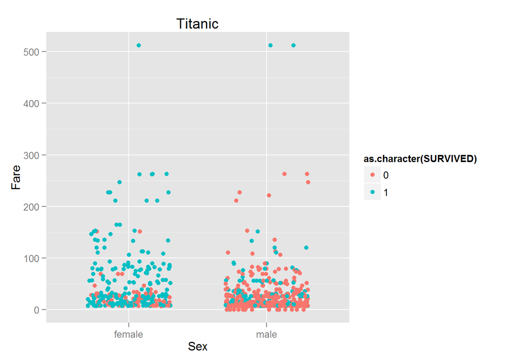

```r
source("../02 Visualizations/TitanicPlot03.R", echo = TRUE)
```

For the Fourth plot the variables are rearranged but the big difference is the addition of a facet command, which creates the 6 seperate plots.

```
##
## > ggplot() + coord_cartesian() + scale_x_discrete() +
## +     scale_y_continuous() + facet_grid(PCLASS ~ SURVIVED, labeller = label_both) +
## +     labs .... [TRUNCATED]
```

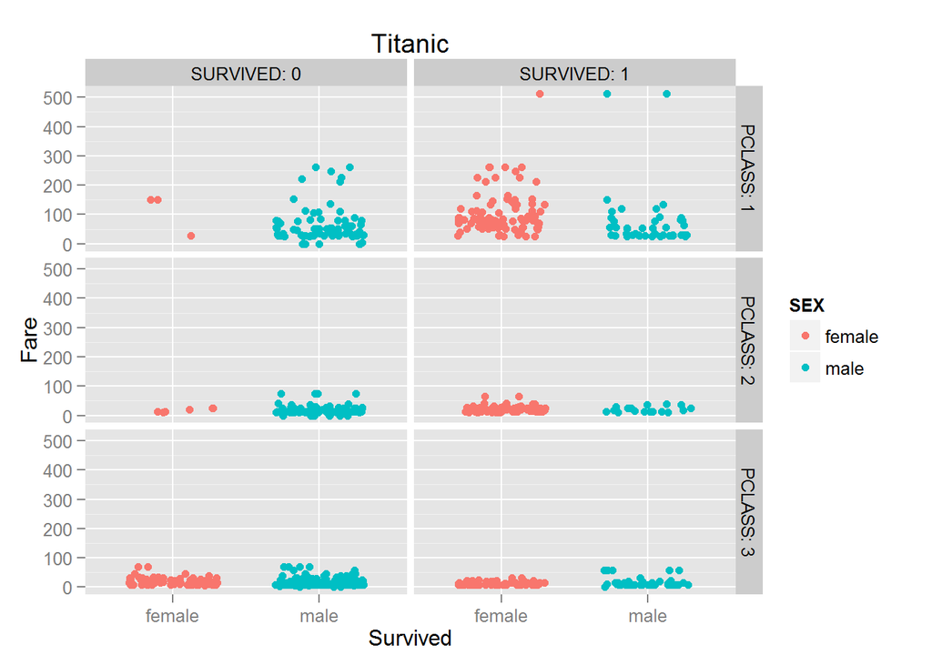

```r
source("../02 Visualizations/TitanicPlot04.R", echo = TRUE)
```

Similar to the Second plot, the fifth plot requires that we once more redefine the dataframe, this time only using entries with an age under 10.

```
##
## > df <- data.frame(fromJSON(getURL(URLencode("129.152.144.84:5001/rest/native/?query=\"select * from titanic where sex is not null and age <= 10\""),  .... [TRUNCATED]
##
## > ggplot() + coord_cartesian() + scale_x_discrete() +
## +     scale_y_continuous() + facet_grid(PCLASS ~ SURVIVED, labeller = label_both) +
## +     labs .... [TRUNCATED]
```

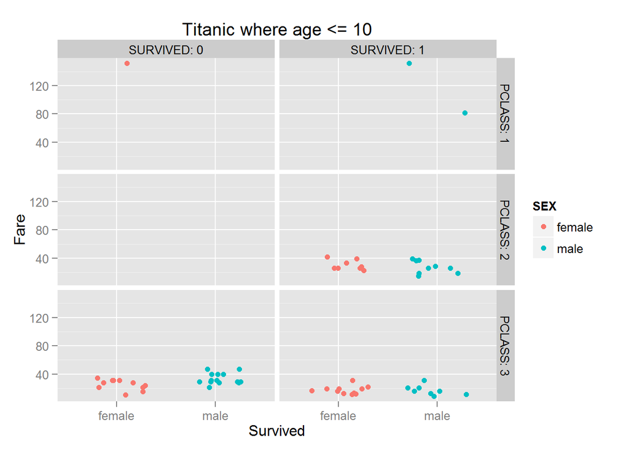

```r
source("../02 Visualizations/TitanicPlot05.R", echo = TRUE)
```

3. We designed the last plot ourselves and it shows the survival rates of people over the age of 50, compared to which class they were in.

The last plot is similar to the fifth plot, though instead of populating the dataframe with the very young passengers, it examines the elderly. The scale and label of the axis remains the same but the data itself changes.

```
##
## > df <- data.frame(fromJSON(getURL(URLencode("129.152.144.84:5001/rest/native/?query=\"select * from titanic where sex is not null and age >= 50\""),  .... [TRUNCATED]
##
## > ggplot() + coord_cartesian() + scale_x_discrete() +
## +     scale_y_continuous() + facet_grid(PCLASS ~ SURVIVED, labeller = label_both) +
## +     labs .... [TRUNCATED]
```

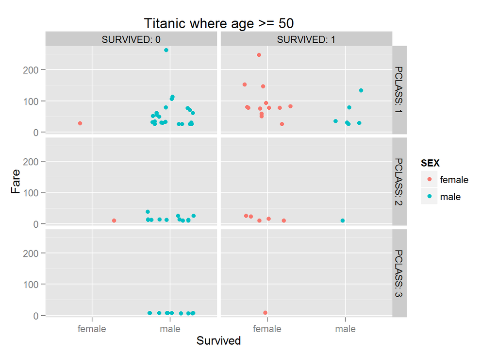

```r
source("../02 Visualizations/TitanicPlot06.R", echo = TRUE)
```